# Which stations and routes are the most popular and who is likely to use them?

## by Jagdeep Singh

## Investigation Overview

The goal for this presentation is to get some idea of which of the routes for the ford go bikes is most likey to be used most and which of the stations is most popular.

## Dataset Overview

The dataset is for the year of 2017 and is has 15 columns, which range from duration of rides to member gender. some will be more useful then others.

## Most popular stations

By plotting the most popular stations for both start and ending points it is possible to see the ponts in the city which will require the most bikes. Also which routes is most like to be taken. San Francisco Caltrain (Townsend St at 4th St) with its two stations ib by far the most used therefore an asuumption can be made that this route will be used by most users.

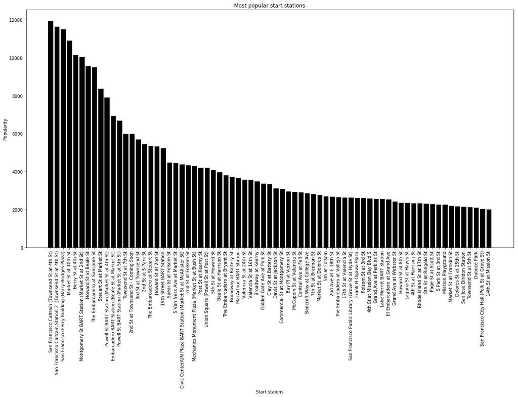

```python
plt.bar(pop_start_stationr.index,pop_start_stationr, color=(0,0,0))
plt.xticks(rotation=90)
fig = plt.gcf()
fig.set_size_inches( 20, 10)
plt.title('Most popular start stations')
plt.xlabel('Start staions')
plt.ylabel('Popularity')
```

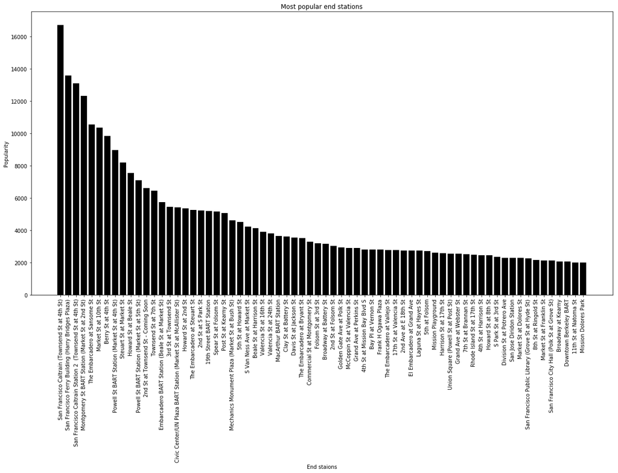

```python
plt.bar(pop_end_stationr.index,pop_end_stationr, color=(0,0,0))
plt.xticks(rotation=90)
fig = plt.gcf()
fig.set_size_inches( 20, 10)
plt.title('Most popular end stations')
plt.xlabel('End staions')
plt.ylabel('Popularity')
```

## The ages range of users

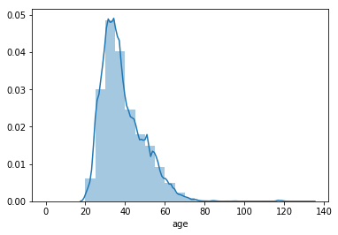

```python
b=np.arange(0,90,5)
sb.distplot(2019-df_copy['member_birth_year'],axlabel='age',bins=b)
```

## Gender of users and if they are customers or subscribers

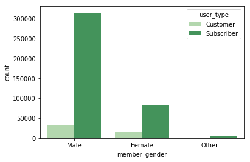

```python
sb.countplot(data = df_copy, x = 'member_gender', hue = 'user_type', palette = 'Greens')
```